# 机器学习纳米学位

### 练习 - 创建一个训练和预测的流水线

为了正确评估你选择的每一个模型的性能，创建一个能够帮助你快速有效地使用不同大小的训练集并在测试集上做预测的训练和测试的流水线是十分重要的。 你在这里实现的功能将会在接下来的部分中被用到。在下面的代码单元中，你将实现以下功能：

- 从[`sklearn.metrics`](http://scikit-learn.org/stable/modules/classes.html#sklearn-metrics-metrics)中导入`fbeta_score`和`accuracy_score`。
- 用样例训练集拟合学习器，并记录训练时间。
- 用学习器来对训练集进行预测并记录预测时间。
- 在最前面的300个*训练数据*上做预测。
- 计算训练数据和测试数据的准确率。
- 计算训练数据和测试数据的F-score。

```python
# TODO：从sklearn中导入两个评价指标 - fbeta_score和accuracy_score
from sklearn.metrics import fbeta_score, accuracy_score

def train_predict(learner, sample_size, X_train, y_train, X_test, y_test):
    '''
    inputs:
       - learner: the learning algorithm to be trained and predicted on
       - sample_size: the size of samples (number) to be drawn from training set
       - X_train: features training set
       - y_train: income training set
       - X_test: features testing set
       - y_test: income testing set
    '''

    results = {}

    # TODO：使用sample_size大小的训练数据来拟合学习器
    # TODO: Fit the learner to the training data using slicing with 'sample_size'
    start = time() # 获得程序开始时间
    learner.fit(X_train[0:sample_size], y_train[0:sample_size])
    end = time() # 获得程序结束时间

    # TODO：计算训练时间
    results['train_time'] = end - start

    # TODO: 得到在测试集上的预测值
    #       然后得到对前300个训练数据的预测结果
    start = time() # 获得程序开始时间
    predictions_test = learner.predict(X_test)
    predictions_train = learner.predict(X_train[0:300])
    end = time() # 获得程序结束时间

    # TODO：计算预测用时
    results['pred_time'] = end - start

    # TODO：计算在最前面的300个训练数据的准确率
    results['acc_train'] = accuracy_score(predictions_train, y_train[0:300])

    # TODO：计算在测试集上的准确率
    results['acc_test'] = accuracy_score(predictions_test, y_test)

    # TODO：计算在最前面300个训练数据上的F-score
    results['f_train'] = fbeta_score(y_train[0:300], predictions_train, beta=0.5)

    # TODO：计算测试集上的F-score
    results['f_test'] = fbeta_score(y_test, predictions_test, beta = 0.5)

    # 成功
    print "{} trained on {} samples.".format(learner.__class__.__name__, sample_size)

    # 返回结果
    return results
```

### 练习：初始模型的评估

在下面的代码单元中，您将需要实现以下功能：

- 导入你在前面讨论的三个监督学习模型。
- 初始化三个模型并存储在`'clf_A'`，`'clf_B'`和`'clf_C'`中。
  - 如果可能对每一个模型都设置一个`random_state`。
  - **注意：**这里先使用每一个模型的默认参数，在接下来的部分中你将需要对某一个模型的参数进行调整。
- 计算记录的数目等于1%，10%，和100%的训练数据，并将这些值存储在`'samples'`中

**注意：**取决于你选择的算法，下面实现的代码可能需要一些时间来运行！

```
SVC trained on 361 samples.
SVC trained on 3617 samples.
SVC trained on 36177 samples.
RandomForestClassifier trained on 361 samples.
RandomForestClassifier trained on 3617 samples.
RandomForestClassifier trained on 36177 samples.
LogisticRegression trained on 361 samples.
LogisticRegression trained on 3617 samples.
LogisticRegression trained on 36177 samples.
```

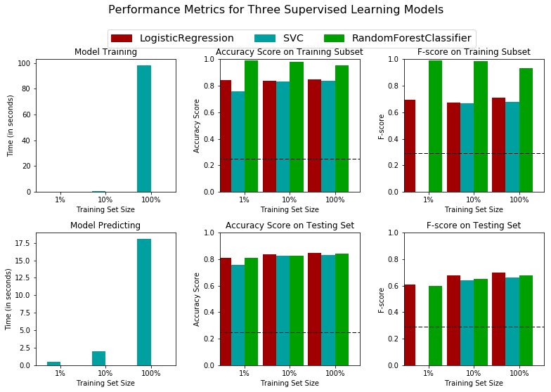

```python
# TODO：从sklearn中导入三个监督学习模型
from sklearn import svm
from sklearn.ensemble import RandomForestClassifier
from sklearn import linear_model
# TODO：初始化三个模型
clf_A = svm.SVC(random_state=2333)
clf_B = RandomForestClassifier(random_state=2333)
clf_C = linear_model.LogisticRegression(random_state=2333)


# TODO：计算1%， 10%， 100%的训练数据分别对应多少点
sample_size = X_train.shape[0]
samples_1 = int(sample_size * 0.01)
samples_10 = int(sample_size * 0.1)
samples_100 = sample_size

# 收集学习器的结果
results = {}
for clf in [clf_A, clf_B, clf_C]:
    clf_name = clf.__class__.__name__
    results[clf_name] = {}
    for i, samples in enumerate([samples_1, samples_10, samples_100]):
        results[clf_name][i] = \
        train_predict(clf, samples, X_train, y_train, X_test, y_test)

# 对选择的三个模型得到的评价结果进行可视化
vs.evaluate(results, accuracy, fscore)
```

## 提高效果

在这最后一节中，您将从三个有监督的学习模型中选择*最好的*模型来使用学生数据。你将在整个训练集（`X_train`和`y_train`）上通过使用网格搜索优化至少调节一个参数以获得一个比没有调节之前更好的F-score。

### 问题 3 - 选择最佳的模型

*基于你前面做的评价，用一到两段向*CharityML*解释这三个模型中哪一个对于判断被调查者的年收入大于\$50,000是最合适的。*  
**提示：**你的答案应该包括关于评价指标，预测/训练时间，以及该算法是否适合这里的数据的讨论。

**回答：** 从测试集的结果来看，三者的差距在大多数情况下差别并不太大。但是在SVM的训练速度相比与另外两个分类器实在是慢的荒唐，而且SVM在数据量过少时F-score异常，故排除使用SVM。由图途中数据来看，不管是acc还是f-score，Logistic回归的性能略身体一筹，而且随机森林明显过拟合。所以Logistic回归训练的模型是最佳的预测模型。

### 问题 4 - 用通俗的话解释模型

*用一到两段话，向*CharityML*用外行也听得懂的话来解释最终模型是如何工作的。你需要解释所选模型的主要特点。例如，这个模型是怎样被训练的，它又是如何做出预测的。避免使用高级的数学或技术术语，不要使用公式或特定的算法名词。*

**回答：** Logistic回归是一种分类算法，在本例中，它的作用就是将收集到的人口信息数据分为两大类：收入大于50k的人群和小于50k的人群，因为收入高的人群捐款的概率更高。想象这些人的数据是散落在一张平面上的点，而实现这个分类，就是要要出一条“线”，作为两个类别的边界，将这些点分为两类，边界的一边是收入高于50k的人群，另一边是收入低于50k的人群。在Lgositic回归开始的时候，计算机会先随机画一条“分界线”，而这条分界线可能并没有很好地将两个类分开。接下来要做的，就是不断调整这条线的位置，使他更好地区分两个点的区域。而当以后我们确定了一新点的位置，也就是有了 一个新人物的数据，我们就能通过这条分界线，知道他属于哪一类，也就是收入是否大于50k了。

### 练习：模型调优

调节选择的模型的参数。使用网格搜索（GridSearchCV）来至少调整模型的重要参数（至少调整一个），这个参数至少需给出并尝试3个不同的值。你要使用整个训练集来完成这个过程。在接下来的代码单元中，你需要实现以下功能：

- 导入[`sklearn.model_selection.GridSearchCV`](http://scikit-learn.org/stable/modules/generated/sklearn.model_selection.GridSearchCV.html)和[`sklearn.metrics.make_scorer`](http://scikit-learn.org/stable/modules/generated/sklearn.metrics.make_scorer.html).
- 初始化你选择的分类器，并将其存储在`clf`中。
  - 如果能够设置的话，设置`random_state`。
- 创建一个对于这个模型你希望调整参数的字典。
  - 例如: parameters = {'parameter' : [list of values]}。
  - **注意：** 如果你的学习器（learner）有 `max_features` 参数，请不要调节它！
- 使用`make_scorer`来创建一个`fbeta_score`评分对象（设置$\beta = 0.5$）。
- 在分类器clf上用'scorer'作为评价函数运行网格搜索，并将结果存储在grid_obj中。
- 用训练集（X_train, y_train）训练grid search object,并将结果存储在`grid_fit`中。

**注意：** 取决于你选择的参数列表，下面实现的代码可能需要花一些时间运行！

```python
# TODO：导入'GridSearchCV', 'make_scorer'和其他一些需要的库
from sklearn.model_selection import GridSearchCV
from sklearn.metrics import make_scorer
# TODO：初始化分类器
clf = linear_model.LogisticRegression(random_state=2333, n_jobs=-1)

# TODO：创建你希望调节的参数列表
parameters = {'C': [1.0, 2.0, 10.0, 20.0], 'max_iter': [100, 200], 'solver': ['newton-cg', 'lbfgs', 'liblinear', 'sag']}

# TODO：创建一个fbeta_score打分对象
scorer = make_scorer(fbeta_score, beta=0.5)

# TODO：在分类器上使用网格搜索，使用'scorer'作为评价函数
grid_obj = GridSearchCV(clf,param_grid=parameters,scoring=scorer)

# TODO：用训练数据拟合网格搜索对象并找到最佳参数
grid_fit = grid_obj.fit(X_train,y_train)

# 得到estimator
best_clf = grid_obj.best_estimator_

# 使用没有调优的模型做预测
predictions = (clf.fit(X_train, y_train)).predict(X_test)
best_predictions = best_clf.predict(X_test)
print 1

# 汇报调参前和调参后的分数
print "Unoptimized model\n------"
print "Accuracy score on testing data: {:.4f}".format(accuracy_score(y_test, predictions))
print "F-score on testing data: {:.4f}".format(fbeta_score(y_test, predictions, beta = 0.5))
print "\nOptimized Model\n------"
print "Final accuracy score on the testing data: {:.4f}".format(accuracy_score(y_test, best_predictions))
print "Final F-score on the testing data: {:.4f}".format(fbeta_score(y_test, best_predictions, beta = 0.5))
```

```
1
Unoptimized model
------
Accuracy score on testing data: 0.8483
F-score on testing data: 0.6993

Optimized Model
------
Final accuracy score on the testing data: 0.8500
Final F-score on the testing data: 0.7024
```

### 问题 5 - 最终模型评估

*你的最优模型在训练数据上的准确率和F-score是多少？这些分数比没有优化的模型好还是差？你优化的结果相比于你在**问题 1**中得到的朴素预测器怎么样？*  
**注意：**请在下面的表格中填写你的结果，然后在答案框中提供讨论。

#### 结果:

[output not shown]

**回答：** 由Logistic回归训练的模型比基准预测器不知道搞到哪里去了。优化模型的acc和f-score比未优化模型高，但是提升只有一很小一点。

## 特征的重要性

在数据上（比如我们这里使用的人口普查的数据）使用监督学习算法的一个重要的任务是决定哪些特征能够提供最强的预测能力。通过专注于一些少量的有效特征和标签之间的关系，我们能够更加简单地理解这些现象，这在很多情况下都是十分有用的。在这个项目的情境下这表示我们希望选择一小部分特征，这些特征能够在预测被调查者是否年收入大于\$50,000这个问题上有很强的预测能力。

选择一个有`feature_importance_`属性（这是一个根据这个选择的分类器来对特征的重要性进行排序的函数）的scikit学习分类器（例如，AdaBoost，随机森林）。在下一个Python代码单元中用这个分类器拟合训练集数据并使用这个属性来决定这个人口普查数据中最重要的5个特征。

### 问题 6 - 观察特征相关性

当**探索数据**的时候，它显示在这个人口普查数据集中每一条记录我们有十三个可用的特征。  
*在这十三个记录中，你认为哪五个特征对于预测是最重要的，你会怎样对他们排序？理由是什么？*

**回答：**我认为最重要的5个特征依次是：education_level, education-num,hours-per-week， occupation，age。我认为教育水平和受教育的长短会很大程度地影响一个人的薪酬，所以受教育多的人更有有高收入；其次是工作时间，工作时间长的可能会会获得高收入，但是有很多工人的工作时间很长，然而收入并不高；然后就是职业，职业和薪酬直接相关，但是相同职业在不同公司，地区和能力的差别会很大程度地影响薪酬；年龄高的人的退休金可能没有工作时高。

### 练习 - 提取特征重要性

选择一个`scikit-learn`中有`feature_importance_`属性的监督学习分类器，这个属性是一个在做预测的时候根据所选择的算法来对特征重要性进行排序的功能。

在下面的代码单元中，你将要实现以下功能：

- 如果这个模型和你前面使用的三个模型不一样的话从sklearn中导入一个监督学习模型。
- 在整个训练集上训练一个监督学习模型。
- 使用模型中的`'.feature_importances_'`提取特征的重要性。

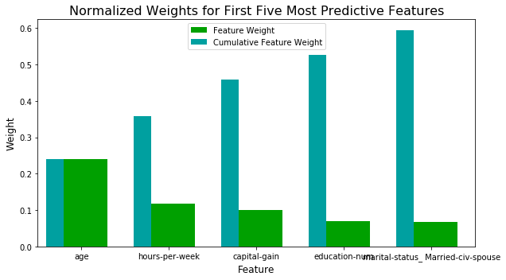

```python
# TODO：导入一个有'feature_importances_'的监督学习模型
from sklearn.ensemble import RandomForestClassifier
# TODO：在训练集上训练一个监督学习模型
model = RandomForestClassifier(random_state=2333)
model.fit(X_train, y_train)

# TODO： 提取特征重要性
importances = model.feature_importances_

# 绘图
vs.feature_plot(importances, X_train, y_train)
```

### 问题 7 - 提取特征重要性

观察上面创建的展示五个用于预测被调查者年收入是否大于\$50,000最相关的特征的可视化图像。 *这五个特征和你在**问题 6**中讨论的特征比较怎么样？如果说你的答案和这里的相近，那么这个可视化怎样佐证了你的想法？如果你的选择不相近，那么为什么你觉得这些特征更加相关？*

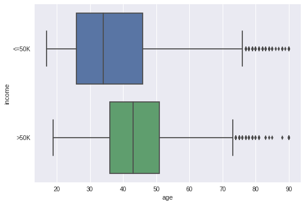

```python
import seaborn as sns
ax = sns.boxplot(x="age", y="income", data=data, orient="h")
```

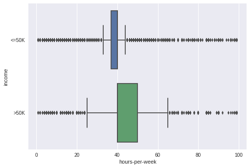

```python
ax = sns.boxplot(x="hours-per-week", y="income", data=data, orient="h")
```

上述的盒图能够佐证`feature_importance_` 得出的结论

### 特征选择

如果我们只是用可用特征的一个子集的话模型表现会怎么样？通过使用更少的特征来训练，在评价指标的角度来看我们的期望是训练和预测的时间会更少。从上面的可视化来看，我们可以看到前五个最重要的特征贡献了数据中**所有**特征中超过一半的重要性。这提示我们可以尝试去*减小特征空间*，并简化模型需要学习的信息。下面代码单元将使用你前面发现的优化模型，并*只使用五个最重要的特征*在相同的训练集上训练模型。

```python
# 导入克隆模型的功能
from sklearn.base import clone

# 减小特征空间
X_train_reduced = X_train[X_train.columns.values[(np.argsort(importances)[::-1])[:5]]]
X_test_reduced = X_test[X_test.columns.values[(np.argsort(importances)[::-1])[:5]]]

# 在前面的网格搜索的基础上训练一个“最好的”模型
clf = (clone(best_clf)).fit(X_train_reduced, y_train)

# 做一个新的预测
reduced_predictions = clf.predict(X_test_reduced)

# 对于每一个版本的数据汇报最终模型的分数
print "Final Model trained on full data\n------"
print "Accuracy on testing data: {:.4f}".format(accuracy_score(y_test, best_predictions))
print "F-score on testing data: {:.4f}".format(fbeta_score(y_test, best_predictions, beta = 0.5))
print "\nFinal Model trained on reduced data\n------"
print "Accuracy on testing data: {:.4f}".format(accuracy_score(y_test, reduced_predictions))
print "F-score on testing data: {:.4f}".format(fbeta_score(y_test, reduced_predictions, beta = 0.5))
```

```
Final Model trained on full data
------
Accuracy on testing data: 0.8500
F-score on testing data: 0.7024

Final Model trained on reduced data
------
Accuracy on testing data: 0.8344
F-score on testing data: 0.6670
```

### 问题 8 - 特征选择的影响

*最终模型在只是用五个特征的数据上和使用所有的特征数据上的F-score和准确率相比怎么样？*  
*如果训练时间是一个要考虑的因素，你会考虑使用部分特征的数据作为你的训练集吗？*

**回答：**acc和f-score都有所下降，其中f-score下降更加明显。虽然训练时间是一个值得考虑的因素，但是因此来牺牲模型的性能我觉得不值得，特别是在一些对精度要求高的领域，我宁愿话更多的时间让模型输出更加可靠。

> **注意：** 当你写完了所有的代码，并且回答了所有的问题。你就可以把你的 iPython Notebook 导出成 HTML 文件。你可以在菜单栏，这样导出**File -> Download as -> HTML (.html)**把这个 HTML 和这个 iPython notebook 一起做为你的作业提交。